# DS 202 HW 2

January 27, 2018

## Cars and mileage

In this homework we will use the `mpg` data set, you can access the data by loading the package `ggplot2` into your R session by executing the command `library(ggplot2)`. The `mpg` data includes information about fuel economy of popular car models for the years 1999 and 2008 as collected by the US Environmental Protection Agency.

Most exercises are from the ggplot2 book section 2.2.1. You might find it helpful for working on the homework to read through this section.

1. Download the RMarkdown file with these homework instructions to use as a template for your work. Make sure to replace “Your Name” in the YAML with your name.
2. List five functions that you could use to get more information about the mpg dataset.
- We can use the average function to find what class of car gets the best highway/city mpg.
- We can use the sum function to see how many total models of car that each manufacturer makes.
- We can use the max function in order see what the highest miles per gallon of any vehical is.
- We can use the min function in order to see the lowest miles per gallon of any vehicle.
- We can use the range function to see the differece in the amount of miles per gallon based on the number of cylinders
2. Using the `ggplot2` package create a scatterplot of `hwy` and `cty` and describe the relationship. Why are there so few points visible? Use a geom that helps reduce the amount of overplotting in the scatterplot.

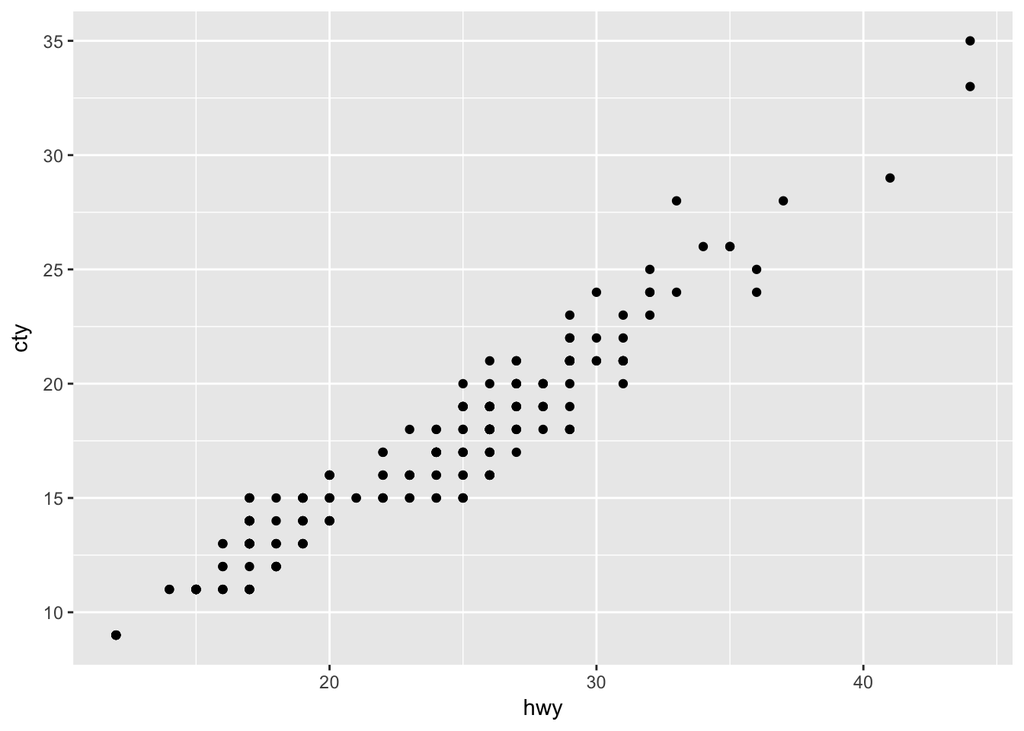

```r
library(ggplot2)
library(classdata)
ggplot(mpg, aes(x=hwy, y=cty))+geom_point()
```

- I would describe the relationship between highway and city mpg as being fairly strong, linear, and positive.
- There are a lot of points that are not visible because there are a lot of models that have the same amount of MPG for both highway and city driving, because of this the points become stacked and in turn are not distinguishable. A good Geom to combat this would be geom_jitter

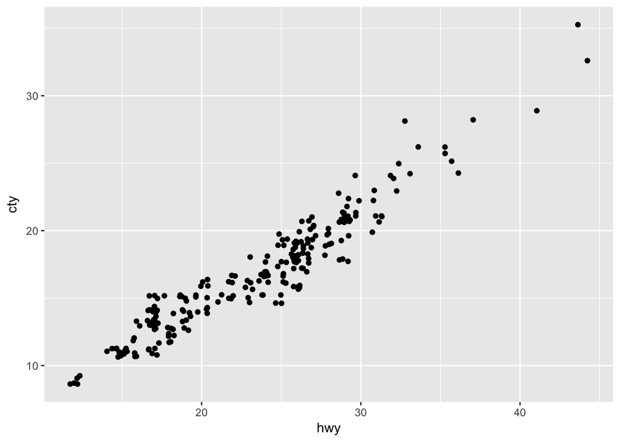

```r
ggplot(aes(x=hwy, y=cty), data = mpg) +geom_jitter()
```

- An intersting observation that I found was that there was a trend that vehicles with a higher MPG had a lower Cylinder count.

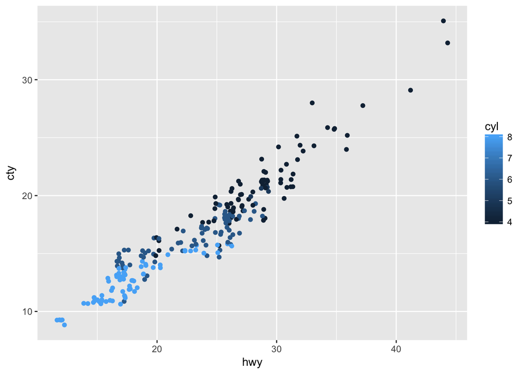

```r
ggplot(aes(x=hwy, y=cty, colour=cyl), data = mpg) +geom_jitter()
```

3. Apart from the US, most countries use fuel consumption (fuel consumed over fixed distance) rather than fuel economy (distance traveled with fixed amount of fuel). How could you convert `cty` and `hwy` into the European standard of liter/100 km? Introduce corresponding variables into the `mpg` data.
- I found that the formula for converting mpg to liters / 100 km is (100 x 3.785411784)/(1.609344 x MPG) so I would simply plug the mpg data for both city and highway into that formula. This is demonstrated below.

```r
mpg$hwyL100km <- (100*3.785411784)/(1.609344*mpg$hwy)
mpg$ctyL100km <- (100*3.785411784)/(1.609344*mpg$cty)
```

4. Are cars in 2008 more fuel efficient than cars in 1999? Expand on your answer in (2) for a visual approach to this question. Note: you are not asked to find numeric answers. Instead, interpret plots.

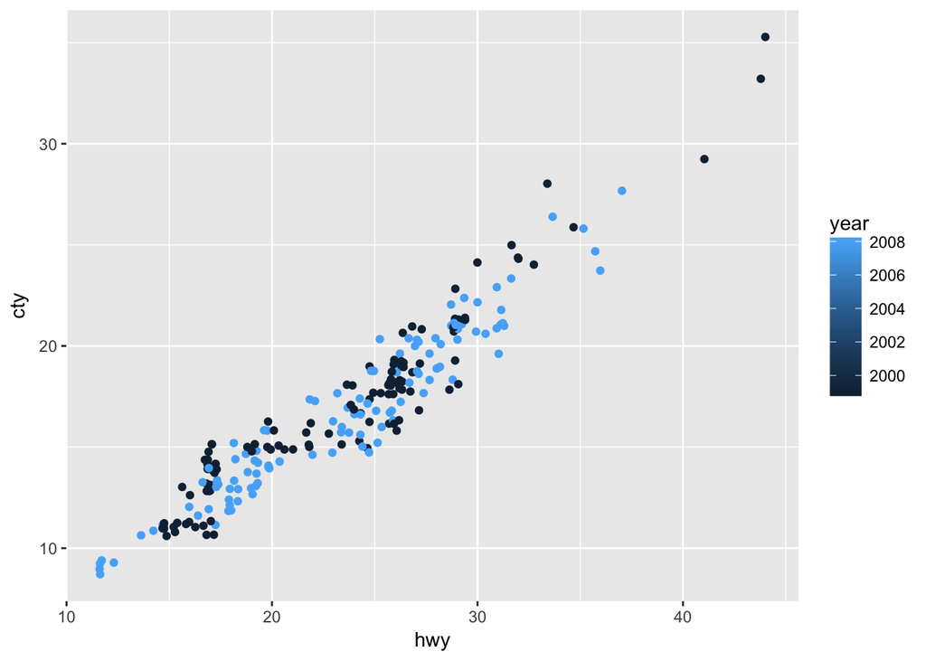

```r
ggplot(aes(x=hwy, y =cty, color = year), data = subset(mpg, year == 2008 | year == 1999), select = c(hwy, cty)) + geom_jitter()
```

- My initial observation is that it doesnt look like there is any real corelation between the year and the amount of miles per gallon, in fact some of the cars from 1999 get more MPG than cars from 2008.

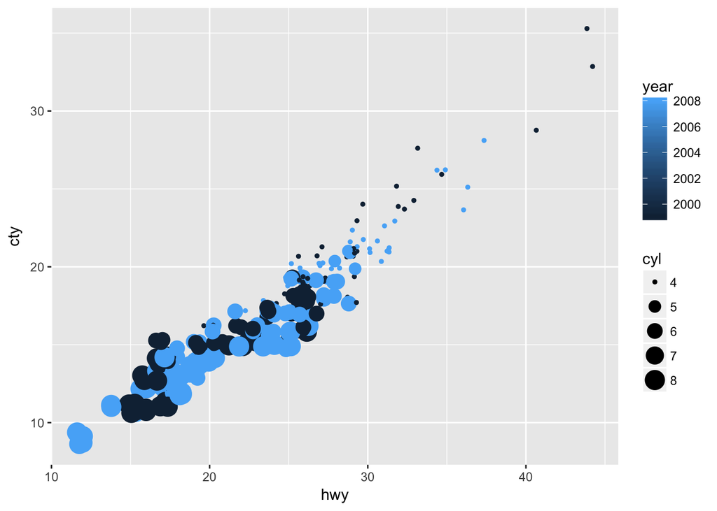

```r
ggplot(aes(x=hwy, y =cty, color = year, size = cyl), data = subset(mpg, year == 2008 | year == 1999), select = c(hwy, cty)) + geom_jitter()
```

- The next plot I made reiterates the point that I made earlier in question 2; the amount of miles per gallon seems to be related closer to the amount of cylinders that the car’s engine has rather than the year that the car was made.
- I found it to be interesting that the lowest MPG’s were cars that were made in 2008 and the cars with the highest were 1999, but the thing that this data says loudest is that the year of the car does not have any significant influence on the MPG ratings
6. Use the `ggplot2` package to create side-by-side boxplots of `cty` by `class`. Describe the relationship in 2-3 sentences. Change the label for the y-axis to ‘city miles per gallon’ (see `?ylab`).

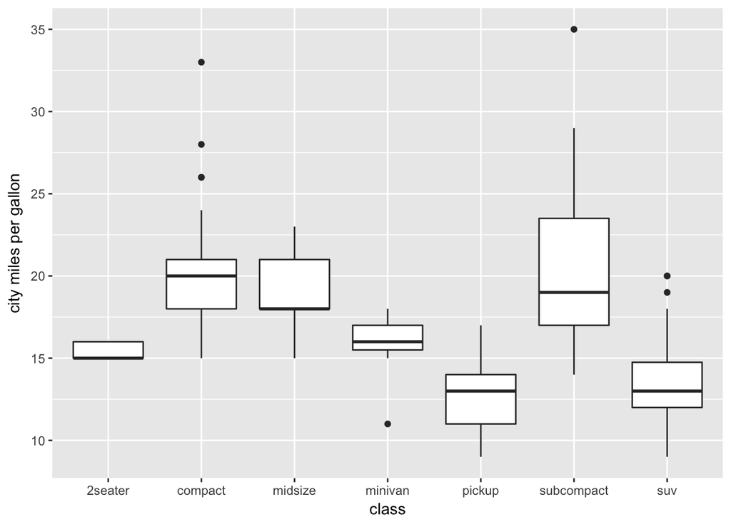

```r
ggplot(aes(x = class, y = cty),data=mpg) + geom_boxplot() + scale_y_continuous(name="city miles per gallon")
```

- The boxplot shows that the different classes of cars kind of fit into smaller groups with very similar ranges for city mpg. I would break these classes down into: 2 seaters and minivans, compact and midsize, and suv and pickups. Subcompact cars have a bigger range in their amount of city MPG than any other class but i would say that they are most similar to compact and midsize vehicles.

Note: your submission is supposed to be fully reproducible, i.e. the TA and I will ‘knit’ your submission in RStudio. Including the link to the image is the tricky part here. Make sure that you don’t use any file structure that depends on your computing environment.

For the submission: submit your solution in an R Markdown file and (just for insurance) submit the corresponding html (or Word) file with it.